# 6Aug_Lab_Session

```python
import numpy as np
import pandas as pd
import matplotlib.pyplot as plt
%matplotlib inline
import seaborn as sns
import warnings
warnings.filterwarnings('ignore')

import sklearn
from sklearn.preprocessing import StandardScaler,LabelEncoder,MinMaxScaler
from sklearn.model_selection import train_test_split
from sklearn.linear_model import LinearRegression
from sklearn.metrics import r2_score
```

```python
df=pd.read_csv(r"C:\Users\Tanush Sujoy\Downloads\archive\tips.csv")
df.head()
```

|  | total_bill | tip | sex | smoker | day | time | size |
| --- | --- | --- | --- | --- | --- | --- | --- |
| 0 | 16.99 | 1.01 | Female | No | Sun | Dinner | 2 |
| 1 | 10.34 | 1.66 | Male | No | Sun | Dinner | 3 |
| 2 | 21.01 | 3.50 | Male | No | Sun | Dinner | 3 |
| 3 | 23.68 | 3.31 | Male | No | Sun | Dinner | 2 |
| 4 | 24.59 | 3.61 | Female | No | Sun | Dinner | 4 |

*1.Make a list of categorical and numerical columns*

```python
df.info()
```

```
<class 'pandas.core.frame.DataFrame'>
RangeIndex: 244 entries, 0 to 243
Data columns (total 7 columns):
 #   Column      Non-Null Count  Dtype
---  ------      --------------  -----
 0   total_bill  244 non-null    float64
 1   tip         244 non-null    float64
 2   sex         244 non-null    object
 3   smoker      244 non-null    object
 4   day         244 non-null    object
 5   time        244 non-null    object
 6   size        244 non-null    int64
dtypes: float64(2), int64(1), object(4)
memory usage: 13.5+ KB
```

```python
categorical_data=list(df.describe(include='O'))
categorical_data
```

```
['sex', 'smoker', 'day', 'time']
```

```python
numerical_data=list(df.describe())
numerical_data
```

```
['total_bill', 'tip', 'size']
```

*Compute average bill amount of each day*

```python
df1=df.copy()
```

```python
df1.isnull().sum()
```

```
total_bill    0
tip           0
sex           0
smoker        0
day           0
time          0
size          0
dtype: int64
```

```python
df1.groupby('day')['total_bill'].mean()
```

```
day
Fri     17.151579
Sat     20.441379
Sun     21.410000
Thur    17.682742
Name: total_bill, dtype: float64
```

*Which gender is more generous in giving tips*

```python
df1.groupby('sex')['tip'].mean()
```

```
sex
Female    2.833448
Male      3.089618
Name: tip, dtype: float64
```

ans :Male is more generous in giving tips

### 4. According to the data, were there more customers for dinner or lunch?

```python
df1['time'].value_counts()
```

```
Dinner    176
Lunch      68
Name: time, dtype: int64
```

# 4 There are more customers for Dinner

### Based on the statistical summary,comment on the variable tip

```python
df1['tip'].describe()
```

```
count    244.000000
mean       2.998279
std        1.383638
min        1.000000
25%        2.000000
50%        2.900000
75%        3.562500
max       10.000000
Name: tip, dtype: float64
```

Lookind at the above statistical data I can say that max-indicates outlier..if we compare the mean=2.99 50%=2.90 there is positive skewness .

# Find the busiest day in terms of the orders

```python
df1['day'].mode()
```

```
0    Sat
Name: day, dtype: object
```

Sat is the busiest day in terms of orders

# 7. Is the variable 'total_bill' skewed?If yes,identify the type of skewness.support your answer with a plot

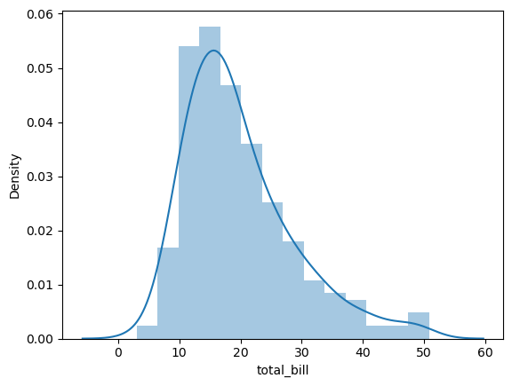

```python
df1.skew()
sns.distplot(df['total_bill'])
plt.show()
```

```python
#Right skewed most bill amt is btw 10usd to 30 usd
```

```python
df1.skew()
```

```
total_bill    1.133213
tip           1.465451
size          1.447882
dtype: float64
```

## 8.Is the tip amount dependent on total bill?Visualise the relationship with appropriate plot and metric and write your finding

```python
df1[['tip','total_bill']].corr()
```

|  | tip | total_bill |
| --- | --- | --- |
| tip | 1.000000 | 0.675734 |
| total_bill | 0.675734 | 1.000000 |

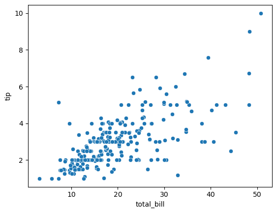

```python
sns.scatterplot(x='total_bill',y='tip',data=df1)
plt.show()
```

Yes from the plot we can say that tip amount is dependent on the total bill,when the bill amount is high tip amount is also high.

### 9. What is the percentage of males and females in the dataset? and display it in the plot

```python
df1['sex'].value_counts(normalize=True)
```

```
Male      0.643443
Female    0.356557
Name: sex, dtype: float64
```

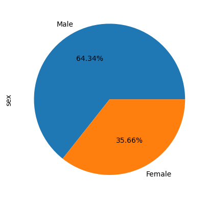

```python
df1['sex'].value_counts(normalize=True).plot(kind='pie',autopct='%.2f%%')
```

#### 10. Compute the gender-wise count based on smoking habits and display it in the plot

```python
df1.groupby('sex')['smoker'].value_counts()
```

```
sex     smoker
Female  No        54
        Yes       33
Male    No        97
        Yes       60
Name: smoker, dtype: int64
```

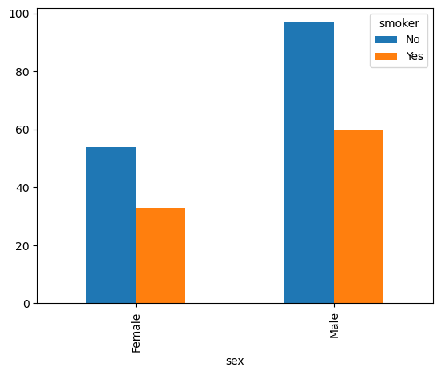

```python
pd.crosstab(df1['sex'],df1['smoker']).plot(kind='bar')
```

### 11. Compute the average tip amount given for different days and display it in the plot.

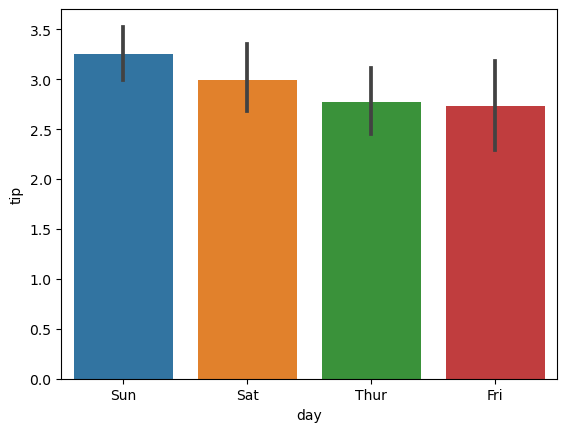

```python
df1.groupby('day')['tip'].mean
sns.barplot(x='day',y='tip',data=df1)
```

#### 12. Is the average bill amount dependent on the size of the group? Visualize the relationship using appropriate plot and write your findings.

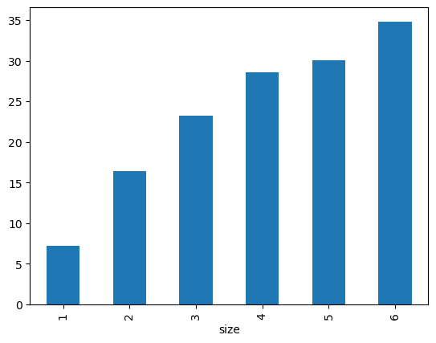

```python
df1.groupby('size')['total_bill'].mean().plot(kind='bar')
```

Yes the average bill amount is positively dependent on group size;the bigger the group size the higher the bill amount

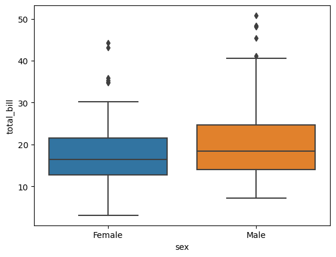

```python
sns.boxplot(x='sex',y='total_bill',data=df1)
plt.show()
```

### 14. Find the maximum bill amount for lunch and dinner on Saturday and Sunday

```python
df1_x = df1.groupby(['time','day'], as_index=False)['total_bill'].max()
df1_x[ (df1_x['day'] == 'Sat') | (df1_x['day'] == 'Sun') ]
```

|  | time | day | total_bill |
| --- | --- | --- | --- |
| 1 | Dinner | Sat | 50.81 |
| 2 | Dinner | Sun | 48.17 |

```python
df1.groupby(['time','day'])['total_bill'].max().loc['Dinner'][['Sat','Sun']]
```

```
day
Sat    50.81
Sun    48.17
Name: total_bill, dtype: float64
```

#### 15. Compute the percentage of missing values in the dataset.

```python
percent_missing=(df1.isnull().sum()*100/len(df1))
percent_missing
```

[output not shown]

### 16. Is there are any duplicate records in the dataset? If yes compute the count of the duplicate records and drop them.

```python
len(df[df1.duplicated()])
```

```
1
```

```python
df.drop_duplicates(inplace=True)
```

```python
len(df[df1.duplicated()])
```

```
0
```

### 17. Is there are any outliers present in the column 'total_bill'? If yes treat them with transformation approach, and plot a boxplot before and after the treatment

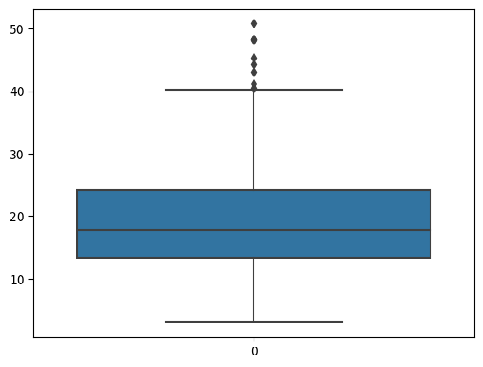

```python
sns.boxplot(df1['total_bill'])
plt.show()
```

```python
df1['total_bill_trans']=np.log(df1['total_bill'])
```

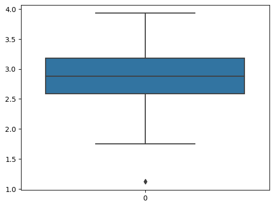

```python
sns.boxplot(df1['total_bill_trans'])
plt.show()
```

```python
df1.head()
```

|  | total_bill | tip | sex | smoker | day | time | size | total_bill_trans |
| --- | --- | --- | --- | --- | --- | --- | --- | --- |
| 0 | 16.99 | 1.01 | Female | No | Sun | Dinner | 2 | 2.832625 |
| 1 | 10.34 | 1.66 | Male | No | Sun | Dinner | 3 | 2.336020 |
| 2 | 21.01 | 3.50 | Male | No | Sun | Dinner | 3 | 3.044999 |
| 3 | 23.68 | 3.31 | Male | No | Sun | Dinner | 2 | 3.164631 |
| 4 | 24.59 | 3.61 | Female | No | Sun | Dinner | 4 | 3.202340 |

### 18. Is there are any outliers present in the column 'tip'? If yes remove them using IQR techinque.

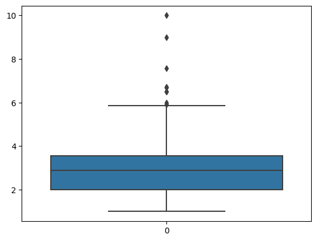

```python
sns.boxplot(df1['tip'])
plt.show()
```

## using IQR method toremove outliers

```python
Q1 = df1['tip'].quantile(0.25)
Q3 = df1['tip'].quantile(0.75)

IQR = Q3 - Q1

lower_whisker = Q1 - (1.5*IQR)
upper_whisker = Q3 + (1.5*IQR)
```

```python
df_out = df.loc[(df['tip'] < upper_whisker) & (df['tip'] > lower_whisker)]
```

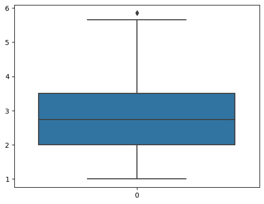

```python
sns.boxplot(df_out['tip'])
plt.show()
```

### 19. Encode the categorical columns in the dataset and print the random 5 samples from the dataframe.

```python
df1_encode=pd.get_dummies(df1,drop_first=True)
df1_encode.head()
```

|  | total_bill | tip | size | total_bill_trans | sex_Male | smoker_Yes | day_Sat | day_Sun | day_Thur | time_Lunch |
| --- | --- | --- | --- | --- | --- | --- | --- | --- | --- | --- |
| 0 | 16.99 | 1.01 | 2 | 2.832625 | 0 | 0 | 0 | 1 | 0 | 0 |
| 1 | 10.34 | 1.66 | 3 | 2.336020 | 1 | 0 | 0 | 1 | 0 | 0 |
| 2 | 21.01 | 3.50 | 3 | 3.044999 | 1 | 0 | 0 | 1 | 0 | 0 |
| 3 | 23.68 | 3.31 | 2 | 3.164631 | 1 | 0 | 0 | 1 | 0 | 0 |
| 4 | 24.59 | 3.61 | 4 | 3.202340 | 0 | 0 | 0 | 1 | 0 | 0 |

### 20. Check the range of the column 'total_bill' and transform the values such that the range will be 1.

```python
total_bill_max=df1['total_bill'].max()
total_bill_min=df1['total_bill'].min()
range_total_bill=total_bill_max-total_bill_min
print(range_total_bill)
```

```
47.74
```

transform the values such that the range will be 1

```python
mm=MinMaxScaler()
#in Standard scaler Mean/Sd will be M=0,Sd=1
#in Min Max Scaler MIn/Max,Range=1
```

```python
df1['total_bill_mm']=mm.fit_transform(df1[['total_bill']])
```

```python
tb_mm_max = df1['total_bill_mm'].max()
tb_mm_min = df1['total_bill_mm'].min()
range_ = tb_mm_max-tb_mm_min
print(range_)
```

```
0.9999999999999999
```

### 21. Load the dataset again by giving the name of the dataframe as "tips_df"

- i) Encode the categorical variables.
- ii) Store the target column (i.e.tip) in the y variable and the rest of the columns in the X variable

```python
tips_df = pd.read_csv('tips.csv')
tips_df.head(2)
```

[output not shown]

```python
X = tips_df.drop('tip',axis=1)
y = tips_df['tip']
```

### 22. Split the dataset into two parts (i.e. 70% train and 30% test), and Standardize the columns "total_bill" and "Size" using the mim_max scaling approach

```python
X_train, X_test, y_train, y_test = train_test_split(X,y,test_size=0.30)
print(X_train.shape,X_test.shape)
print(y_train.shape,y_test.shape)

## Scaling the data using min max scaling
mm = MinMaxScaler()

X_train.iloc[:,:2] = mm.fit_transform(X_train.iloc[:,:2])
X_test.iloc[:,:2] = mm.transform(X_test.iloc[:,:2])
```

[output not shown]

### 23. Train a linear regression model using the training data and print the r_squared value of the prediction on the test data.

```python
lr = LinearRegression()
lr.fit(X_train,y_train)
```

```python
pred = lr.predict(X_test)
print('r2-score test:', r2_score(y_test,pred))
```

[output not shown]